# Binary Classification Model for Census Income Using R Take 1

David Lowe

August 6, 2018

Template Credit: Adapted from a template made available by Dr. Jason Brownlee of Machine Learning Mastery. [http://machinelearningmastery.com/]

SUMMARY: The purpose of this project is to construct a prediction model using various machine learning algorithms and to document the end-to-end steps using a template. The Census Income dataset is a classic binary classification situation where we are trying to predict one of the two possible outcomes.

INTRODUCTION: This data was extracted from the 1994 Census Bureau database by Ronny Kohavi and Barry Becker (Data Mining and Visualization, Silicon Graphics). A set of reasonably clean records was extracted using the following conditions: ((AAGE>16) && (AGI>100) && (AFNLWGT>1) && (HRSWK>0)). The prediction task is to determine whether a person makes over 50K a year.

This dataset has many cells with missing values, so we will examine the models by deleting the rows with missing cells. This iteration of the project will produce a set of baseline results that we can use to compare with other data cleaning methods.

For this project, the Stochastic Gradient Boosting ensemble algorithm yielded consistently top-notch training and validation results, which warrant the additional processing required by the algorithm.

Dataset Used: Census Income Data Set

Dataset ML Model: Binary classification with numerical and categorical attributes

Dataset Reference: https://archive.ics.uci.edu/ml/datasets/Census+Income

One potential source of performance benchmark: https://www.kaggle.com/uciml/adult-census-income

The project aims to touch on the following areas:

1. Document a predictive modeling problem end-to-end.
2. Explore data cleaning and transformation options
3. Explore non-ensemble and ensemble algorithms for baseline model performance
4. Explore algorithm tuning techniques for improving model performance

Any predictive modeling machine learning project genrally can be broken down into about six major tasks:

1. Prepare Problem
2. Summarize Data
3. Prepare Data
4. Model and Evaluate Algorithms
5. Improve Accuracy or Results
6. Finalize Model and Present Results

## 1. Prepare Problem

### 1.a) Load libraries

```r
library(caret)
```

```r
library(corrplot)
library(ROCR)
```

### 1.b) Load dataset

```r
startTimeScript <- proc.time()

# Import the training dataset, supply the attribue names, and strip the blanks from the cells
entireDataset <- read.csv("adult.data", sep=",", header=FALSE, na.strings=" ?", stringsAsFactors=FALSE)
colnames(entireDataset) <- c("age", "workclass", "fnlwgt", "education", "education_num", "marital_status", "occupation", "relationship", "race", "sex", "capital_gain", "capital_loss", "hours_per_week", "native_country", "income")
entireDataset$workclass <- gsub('\\s+', '', entireDataset$workclass)
entireDataset$education <- gsub('\\s+', '', entireDataset$education)
entireDataset$marital_status <- gsub('\\s+', '', entireDataset$marital_status)
entireDataset$occupation <- gsub('\\s+', '', entireDataset$occupation)
entireDataset$relationship <- gsub('\\s+', '', entireDataset$relationship)
entireDataset$race <- gsub('\\s+', '', entireDataset$race)
entireDataset$sex <- gsub('\\s+', '', entireDataset$sex)
entireDataset$native_country <- gsub('\\s+', '', entireDataset$native_country)
entireDataset$income <- gsub('\\s+', '', entireDataset$income)

# Import the test dataset, supply the attribue names, and strip the blanks from the cells
testDataset <- read.csv("adult.test", sep=",", header=TRUE, na.strings=" ?", stringsAsFactors=FALSE)
colnames(testDataset) <- c("age", "workclass", "fnlwgt", "education", "education_num", "marital_status", "occupation", "relationship", "race", "sex", "capital_gain", "capital_loss", "hours_per_week", "native_country", "income")
testDataset$workclass <- gsub('\\s+', '', testDataset$workclass)
testDataset$education <- gsub('\\s+', '', testDataset$education)
testDataset$marital_status <- gsub('\\s+', '', testDataset$marital_status)
testDataset$occupation <- gsub('\\s+', '', testDataset$occupation)
testDataset$relationship <- gsub('\\s+', '', testDataset$relationship)
testDataset$race <- gsub('\\s+', '', testDataset$race)
testDataset$sex <- gsub('\\s+', '', testDataset$sex)
testDataset$native_country <- gsub('\\s+', '', testDataset$native_country)
testDataset$income <- gsub('\\s+', '', testDataset$income)

# Rename the class/target column to a standard label
colnames(entireDataset)[ncol(entireDataset)] <- "targetVar"
colnames(testDataset)[ncol(testDataset)] <- "targetVar"

# Use variable totCol to hold the number of columns in the dataframe
totCol <- ncol(entireDataset)
```

## 2. Summarize Data

To gain a better understanding of the data that we have on-hand, we will leverage a number of descriptive statistics and data visualization techniques. The plan is to use the results to consider new questions, review assumptions, and validate hypotheses that we can investigate later with specialized models.

### 2.a) Descriptive statistics

#### 2.a.i) Peek at the data itself.

```r
head(entireDataset)
```

```
##   age        workclass fnlwgt education education_num     marital_status
## 1  39        State-gov  77516 Bachelors            13      Never-married
## 2  50 Self-emp-not-inc  83311 Bachelors            13 Married-civ-spouse
## 3  38          Private 215646   HS-grad             9           Divorced
## 4  53          Private 234721      11th             7 Married-civ-spouse
## 5  28          Private 338409 Bachelors            13 Married-civ-spouse
## 6  37          Private 284582   Masters            14 Married-civ-spouse
##          occupation  relationship  race    sex capital_gain capital_loss
## 1      Adm-clerical Not-in-family White   Male         2174            0
## 2   Exec-managerial       Husband White   Male            0            0
## 3 Handlers-cleaners Not-in-family White   Male            0            0
## 4 Handlers-cleaners       Husband Black   Male            0            0
## 5    Prof-specialty          Wife Black Female            0            0
## 6   Exec-managerial          Wife White Female            0            0
##   hours_per_week native_country targetVar
## 1             40  United-States     <=50K
## 2             13  United-States     <=50K
## 3             40  United-States     <=50K
## 4             40  United-States     <=50K
## 5             40           Cuba     <=50K
## 6             40  United-States     <=50K
```

#### 2.a.ii) Dimensions of the dataset.

```r
dim(entireDataset)
```

```
## [1] 32561    15
```

#### 2.a.iii) Types of the attributes.

```r
sapply(entireDataset, class)
```

```
##            age      workclass         fnlwgt      education  education_num
##      "integer"    "character"      "integer"    "character"      "integer"
## marital_status     occupation   relationship           race            sex
##    "character"    "character"    "character"    "character"    "character"
##   capital_gain   capital_loss hours_per_week native_country      targetVar
##      "integer"      "integer"      "integer"    "character"    "character"
```

#### 2.a.iv) Statistical summary of all attributes.

```r
summary(entireDataset)
```

```
##       age         workclass             fnlwgt         education
##  Min.   :17.00   Length:32561       Min.   :  12285   Length:32561
##  1st Qu.:28.00   Class :character   1st Qu.: 117827   Class :character
##  Median :37.00   Mode  :character   Median : 178356   Mode  :character
##  Mean   :38.58                      Mean   : 189778
##  3rd Qu.:48.00                      3rd Qu.: 237051
##  Max.   :90.00                      Max.   :1484705
##  education_num   marital_status      occupation        relationship
##  Min.   : 1.00   Length:32561       Length:32561       Length:32561
##  1st Qu.: 9.00   Class :character   Class :character   Class :character
##  Median :10.00   Mode  :character   Mode  :character   Mode  :character
##  Mean   :10.08
##  3rd Qu.:12.00
##  Max.   :16.00
##      race               sex             capital_gain    capital_loss
##  Length:32561       Length:32561       Min.   :    0   Min.   :   0.0
##  Class :character   Class :character   1st Qu.:    0   1st Qu.:   0.0
##  Mode  :character   Mode  :character   Median :    0   Median :   0.0
##                                        Mean   : 1078   Mean   :  87.3
##                                        3rd Qu.:    0   3rd Qu.:   0.0
##                                        Max.   :99999   Max.   :4356.0
##  hours_per_week  native_country      targetVar
##  Min.   : 1.00   Length:32561       Length:32561
##  1st Qu.:40.00   Class :character   Class :character
##  Median :40.00   Mode  :character   Mode  :character
##  Mean   :40.44
##  3rd Qu.:45.00
##  Max.   :99.00
```

#### 2.a.v) Summarize the levels of the class attribute.

```r
entireDataset_x <- entireDataset[,1:(totCol-1)]
entireDataset_y <- entireDataset[,totCol]
cbind(freq=table(entireDataset_y), percentage=prop.table(table(entireDataset_y))*100)
```

```
##        freq percentage
## <=50K 24720   75.91904
## >50K   7841   24.08096
```

#### 2.a.vi) Count missing values.

```r
sapply(entireDataset, function(x) sum(is.na(x)))
```

```
##            age      workclass         fnlwgt      education  education_num
##              0           1836              0              0              0
## marital_status     occupation   relationship           race            sex
##              0           1843              0              0              0
##   capital_gain   capital_loss hours_per_week native_country      targetVar
##              0              0              0            583              0
```

### 2.b) Data visualizations

#### 2.b.i) Univariate plots to better understand each attribute.

```r
# Set up a variable for the total number of attribute columns (totAttr)
totAttr <- totCol-1
# Set up the number of row and columns for visualization display. dispRow * dispCol should be >= totAttr
dispCol <- 5
if (totAttr%%dispCol == 0) {
dispRow <- totAttr%/%dispCol
} else {
dispRow <- (totAttr%/%dispCol) + 1
}
cat("Will attempt to create graphics grid (col x row): ", dispCol, ' by ', dispRow)
```

```
## Will attempt to create graphics grid (col x row):  5  by  3
```

```r
# Boxplots for each attribute
#par(mfrow=c(dispRow,dispCol))
#for(i in 1:totAttr) {
#   boxplot(entireDataset[,i], main=names(entireDataset)[i])
#}
```

```r
# Histograms each attribute
#par(mfrow=c(dispRow,dispCol))
#for(i in 1:totAttr) {
#   hist(entireDataset[,i], main=names(entireDataset)[i])
#}
```

```r
# Density plot for each attribute
#par(mfrow=c(dispRow,dispCol))
#for(i in 1:totAttr) {
#   plot(density(entireDataset[,i]), main=names(entireDataset)[i])
#}
```

#### 2.b.ii) Multivariate plots to better understand the relationships between attributes

```r
# Scatterplot matrix colored by class
#pairs(targetVar~., data=entireDataset, col=entireDataset$targetVar)
```

```r
# Box and whisker plots for each attribute by class
#scales <- list(x=list(relation="free"), y=list(relation="free"))
#featurePlot(x=entireDataset_x, y=entireDataset_y, plot="box", scales=scales)
```

```r
# Density plots for each attribute by class value
#featurePlot(x=entireDataset_x, y=entireDataset_y, plot="density", scales=scales)
```

```r
# Correlation plot
#correlations <- cor(entireDataset_x)
#corrplot(correlations, method="circle")
```

## 3. Prepare Data

Some dataset may require additional preparation activities that will best exposes the structure of the problem and the relationships between the input attributes and the output variable. Some data-prep tasks might include:

- Cleaning data by removing duplicates, marking missing values and even imputing missing values.
- Feature selection where redundant features may be removed.
- Data transforms where attributes are scaled or redistributed in order to best expose the structure of the problem later to learning algorithms.

### 3.a) Data Cleaning

```r
# First we delete rows with missing values
entireDataset <- entireDataset[complete.cases(entireDataset), ]
dim(entireDataset)
```

```
## [1] 30162    15
```

```r
testDataset <- testDataset[complete.cases(testDataset), ]
dim(testDataset)
```

```
## [1] 15059    15
```

```r
# As it turned out, the training and test datasets had slightly different class labels.
# The training dataset had <=50K and >50K, where the test dataset had <=50K. and >50K. (with extra period).
# We need to make sure both datasets labels the classes the same way.
testDataset$targetVar[testDataset$targetVar=="<=50K."] <- "<=50K"
testDataset$targetVar[testDataset$targetVar==">50K."] <- ">50K"

# Impute missing values
#entireDataset$some_col <- with(entireDataset, impute(some_col, mean))
```

### 3.b) Feature Selection

```r
# Not applicable for this iteration of the project.
```

### 3.c) Data Transforms

```r
# Setting some of the columns from string to categorical attributes
entireDataset$workclass <- as.factor(entireDataset$workclass)
entireDataset$education <- as.factor(entireDataset$education)
entireDataset$marital_status <- as.factor(entireDataset$marital_status)
entireDataset$occupation <- as.factor(entireDataset$occupation)
entireDataset$relationship <- as.factor(entireDataset$relationship)
entireDataset$race <- as.factor(entireDataset$race)
entireDataset$sex <- as.factor(entireDataset$sex)
entireDataset$native_country <- as.factor(entireDataset$native_country)
entireDataset$targetVar <- as.factor(entireDataset$targetVar)

testDataset$workclass <- as.factor(testDataset$workclass)
testDataset$education <- as.factor(testDataset$education)
testDataset$marital_status <- as.factor(testDataset$marital_status)
testDataset$occupation <- as.factor(testDataset$occupation)
testDataset$relationship <- as.factor(testDataset$relationship)
testDataset$race <- as.factor(testDataset$race)
testDataset$sex <- as.factor(testDataset$sex)
testDataset$native_country <- as.factor(testDataset$native_country)
testDataset$targetVar <- as.factor(testDataset$targetVar)
```

### 3.d) Split-out training and validation datasets

We create a training dataset (variable name “training”) and a validation dataset (variable name “validation”).

```r
seedNum <- 888
set.seed(seedNum)

# Create a list of the rows in the original dataset we can use for training
#training_index <- createDataPartition(entireDataset$targetVar, p=0.70, list=FALSE)

# Use 70% of data to training and testing the models
training <- entireDataset

# Select the remaining 30% of the data for validation
validation <- testDataset
```

```r
proc.time()-startTimeScript
```

```
##    user  system elapsed
##    1.41    0.28    1.72
```

## 4. Model and Evaluate Algorithms

After the data-prep, we next work on finding a workable model by evaluating a subset of machine learning algorithms that are good at exploiting the structure of the training. The typical evaluation tasks include:

- Defining test options such as cross validation and the evaluation metric to use.
- Spot checking a suite of linear and nonlinear machine learning algorithms.
- Comparing the estimated accuracy of algorithms.

Linear Algorithm: Logistic Regression

Non-Linear Algorithms: Decision Trees (CART), k-Nearest Neighbors, and Support Vector Machine

The random number seed is reset before each run to ensure that the evaluation of each algorithm is performed using the same data splits. It ensures the results are directly comparable.

### 4.a) Set test options and evaluation metric

```r
# Run algorithms using 10-fold cross validation
control <- trainControl(method="repeatedcv", number=10, repeats=3)
metricTarget <- "Accuracy"
```

### 4.b) Generate models using linear algorithms

```r
# Logistic Regression (Classification)
startTimeModule <- proc.time()
set.seed(seedNum)
fit.glm <- train(targetVar~., data=training, method="glm", metric=metricTarget, trControl=control)
proc.time()-startTimeModule
```

```
##    user  system elapsed
##  142.25    4.07  146.43
```

### 4.c) Generate models using nonlinear algorithms

```r
# Decision Tree - CART (Regression/Classification)
startTimeModule <- proc.time()
set.seed(seedNum)
fit.cart <- train(targetVar~., data=training, method="rpart", metric=metricTarget, trControl=control)
proc.time()-startTimeModule
```

```
##    user  system elapsed
##   40.47    1.08   41.56
```

```r
# k-Nearest Neighbors (Regression/Classification)
startTimeModule <- proc.time()
set.seed(seedNum)
fit.knn <- train(targetVar~., data=training, method="knn", metric=metricTarget, trControl=control)
proc.time()-startTimeModule
```

```
##    user  system elapsed
## 2267.13    0.77 2268.54
```

```r
# Support Vector Machine (Regression/Classification)
startTimeModule <- proc.time()
set.seed(seedNum)
fit.svm <- train(targetVar~., data=training, method="svmRadial", metric=metricTarget, trControl=control)
proc.time()-startTimeModule
```

```
##     user   system  elapsed
## 17331.14   116.60 17455.56
```

### 4.d) Generate models using ensemble algorithms

In this section, we will explore the use and tuning of ensemble algorithms to see whether we can improve the results.

```r
# Bagged CART (Regression/Classification)
startTimeModule <- proc.time()
set.seed(seedNum)
fit.bagcart <- train(targetVar~., data=training, method="treebag", metric=metricTarget, trControl=control)
proc.time()-startTimeModule
```

```
##    user  system elapsed
## 1405.84   15.60 1422.00
```

```r
# Random Forest (Regression/Classification)
startTimeModule <- proc.time()
set.seed(seedNum)
fit.rf <- train(targetVar~., data=training, method="rf", metric=metricTarget, trControl=control)
proc.time()-startTimeModule
```

```
##     user   system  elapsed
## 28736.01    45.05 28793.26
```

```r
# Stochastic Gradient Boosting (Regression/Classification)
startTimeModule <- proc.time()
set.seed(seedNum)
fit.gbm <- train(targetVar~., data=training, method="gbm", metric=metricTarget, trControl=control, verbose=F)
proc.time()-startTimeModule
```

```
##    user  system elapsed
## 1036.66    1.31 1038.50
```

### 4.e) Compare baseline algorithms

```r
results <- resamples(list(LR=fit.glm, CART=fit.cart, kNN=fit.knn, SVM=fit.svm, BagCART=fit.bagcart, RF=fit.rf, GBM=fit.gbm))
summary(results)
```

```
##
## Call:
## summary.resamples(object = results)
##
## Models: LR, CART, kNN, SVM, BagCART, RF, GBM
## Number of resamples: 30
##
## Accuracy
##              Min.   1st Qu.    Median      Mean   3rd Qu.      Max. NA's
## LR      0.8355438 0.8438070 0.8491630 0.8480204 0.8521220 0.8594630    0
## CART    0.8220086 0.8302528 0.8350738 0.8342729 0.8381268 0.8478117    0
## kNN     0.7755305 0.7799237 0.7810376 0.7822095 0.7845771 0.7927719    0
## SVM     0.7456897 0.8396187 0.8438329 0.8351780 0.8475179 0.8568114    0
## BagCART 0.8418435 0.8465683 0.8496602 0.8492029 0.8513514 0.8591316    0
## RF      0.8478117 0.8522756 0.8546089 0.8556349 0.8602570 0.8660477    0
## GBM     0.8448276 0.8582560 0.8610973 0.8611938 0.8638548 0.8750414    0
##
## Kappa
##               Min.   1st Qu.    Median      Mean   3rd Qu.      Max. NA's
## LR      0.53894225 0.5581165 0.5697994 0.5682558 0.5782058 0.6010681    0
## CART    0.44864072 0.4791960 0.4957988 0.4956388 0.5141453 0.5372774    0
## kNN     0.25582291 0.2661619 0.2769421 0.2767209 0.2861009 0.3063103    0
## SVM     0.04148359 0.5345549 0.5480121 0.4987831 0.5560928 0.5857116    0
## BagCART 0.55398117 0.5707076 0.5795571 0.5772244 0.5852158 0.6029411    0
## RF      0.57113435 0.5842805 0.5918951 0.5932313 0.6021554 0.6227004    0
## GBM     0.55542705 0.5909261 0.5991053 0.5995601 0.6081402 0.6417347    0
```

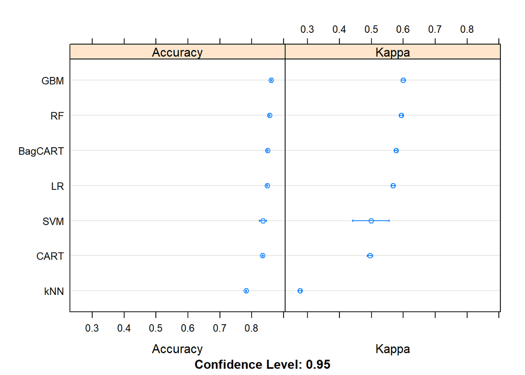

```r
dotplot(results)
```

## 5. Improve Accuracy or Results

After we achieve a short list of machine learning algorithms with good level of accuracy, we can leverage ways to improve the accuracy of the models.

Using the three best-perfoming algorithms from the previous section, we will Search for a combination of parameters for each algorithm that yields the best results.

### 5.a) Algorithm Tuning

Finally, we will tune the best-performing algorithms from each group further and see whether we can get more accuracy out of them.

```r
# Tuning algorithm #1 - Bagged CART
# Bagged CART does not use specialized tuning parameters
startTimeModule <- proc.time()
set.seed(seedNum)
fit.final1 <- fit.bagcart
print(fit.final1)
```

```
## Bagged CART
##
## 30162 samples
##    14 predictor
##     2 classes: '<=50K', '>50K'
##
## No pre-processing
## Resampling: Cross-Validated (10 fold, repeated 3 times)
## Summary of sample sizes: 27146, 27147, 27146, 27146, 27146, 27146, ...
## Resampling results:
##
##   Accuracy   Kappa
##   0.8492029  0.5772244
```

```r
proc.time()-startTimeModule
```

```
##    user  system elapsed
##    0.02    0.00    0.02
```

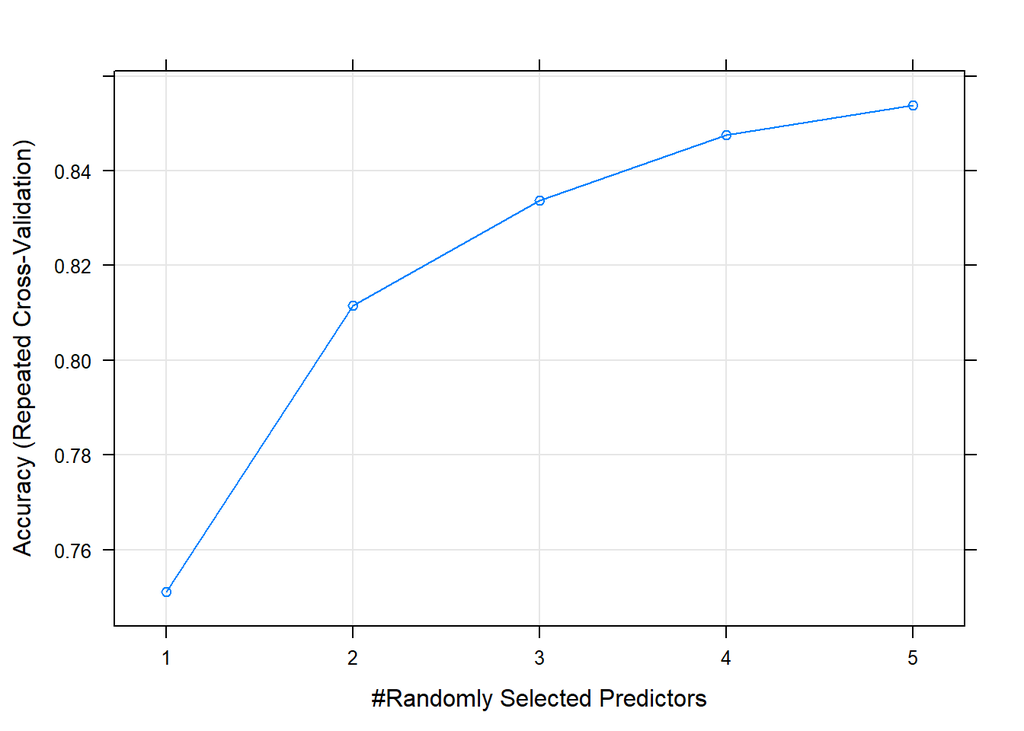

```r
# Tuning algorithm #2 - Random Forest
startTimeModule <- proc.time()
set.seed(seedNum)
grid <- expand.grid(mtry = c(1:5))
fit.final2 <- train(targetVar~., data=training, method="rf", metric=metricTarget, tuneGrid=grid, trControl=control)
plot(fit.final2)
```

```r
print(fit.final2)
```

```
## Random Forest
##
## 30162 samples
##    14 predictor
##     2 classes: '<=50K', '>50K'
##
## No pre-processing
## Resampling: Cross-Validated (10 fold, repeated 3 times)
## Summary of sample sizes: 27146, 27147, 27146, 27146, 27146, 27146, ...
## Resampling results across tuning parameters:
##
##   mtry  Accuracy   Kappa
##   1     0.7510775  0.0000000
##   2     0.8115066  0.3534396
##   3     0.8336758  0.4788515
##   4     0.8475231  0.5413430
##   5     0.8538778  0.5695403
##
## Accuracy was used to select the optimal model using the largest value.
## The final value used for the model was mtry = 5.
```

```r
proc.time()-startTimeModule
```

```
##     user   system  elapsed
## 26970.72    78.40 27058.18
```

```r
# Tuning algorithm #3 - Stochastic Gradient Boosting
startTimeModule <- proc.time()
set.seed(seedNum)
grid <- expand.grid(.n.trees=c(50, 100, 200), .shrinkage=c(0.01, 0.05, 0.1), .interaction.depth=c(1, 2, 3), .n.minobsinnode=c(3, 5, 7))
fit.final3 <- train(targetVar~., data=training, method="gbm", metric=metricTarget, tuneGrid=grid, trControl=control, verbose=F)
```

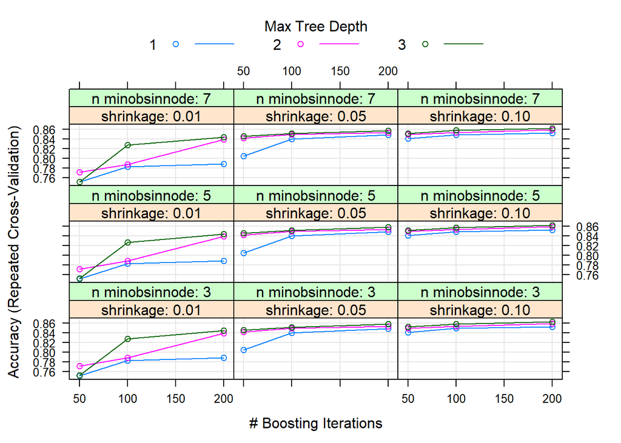

```r
plot(fit.final3)
```

```r
print(fit.final3)
```

```
## Stochastic Gradient Boosting
##
## 30162 samples
##    14 predictor
##     2 classes: '<=50K', '>50K'
##
## No pre-processing
## Resampling: Cross-Validated (10 fold, repeated 3 times)
## Summary of sample sizes: 27146, 27147, 27146, 27146, 27146, 27146, ...
## Resampling results across tuning parameters:
##
##   shrinkage  interaction.depth  n.minobsinnode  n.trees  Accuracy
##   0.01       1                  3                50      0.7510775
##   0.01       1                  3               100      0.7824196
##   0.01       1                  3               200      0.7881552
##   0.01       1                  5                50      0.7510775
##   0.01       1                  5               100      0.7825301
##   0.01       1                  5               200      0.7882104
##   0.01       1                  7                50      0.7510775
##   0.01       1                  7               100      0.7824860
##   0.01       1                  7               200      0.7882104
##   0.01       2                  3                50      0.7713018
##   0.01       2                  3               100      0.7880226
##   0.01       2                  3               200      0.8393674
##   0.01       2                  5                50      0.7713238
##   0.01       2                  5               100      0.7880115
##   0.01       2                  5               200      0.8395331
##   0.01       2                  7                50      0.7715449
##   0.01       2                  7               100      0.7880226
##   0.01       2                  7               200      0.8396767
##   0.01       3                  3                50      0.7517298
##   0.01       3                  3               100      0.8275970
##   0.01       3                  3               200      0.8446609
##   0.01       3                  5                50      0.7517517
##   0.01       3                  5               100      0.8269015
##   0.01       3                  5               200      0.8442409
##   0.01       3                  7                50      0.7517517
##   0.01       3                  7               100      0.8278076
##   0.01       3                  7               200      0.8444067
##   0.05       1                  3                50      0.8046106
```

[output cut: 124 more lines]

```
##   0.56838421
##   0.59324448
##   0.55852253
##   0.58537791
##   0.60487135
##   0.55794331
##   0.58540798
##   0.60487700
##   0.55832303
##   0.58745677
##   0.60482602
##
## Accuracy was used to select the optimal model using the largest value.
## The final values used for the model were n.trees = 200,
##  interaction.depth = 3, shrinkage = 0.1 and n.minobsinnode = 3.
```

```r
proc.time()-startTimeModule
```

```
##     user   system  elapsed
## 11908.13    10.58 11921.61
```

### 5.d) Compare Algorithms After Tuning

```r
results <- resamples(list(BagCART=fit.final1, RF=fit.final2, GBM=fit.final3))
summary(results)
```

```
##
## Call:
## summary.resamples(object = results)
##
## Models: BagCART, RF, GBM
## Number of resamples: 30
##
## Accuracy
##              Min.   1st Qu.    Median      Mean   3rd Qu.      Max. NA's
## BagCART 0.8418435 0.8465683 0.8496602 0.8492029 0.8513514 0.8591316    0
## RF      0.8454907 0.8492913 0.8547745 0.8538778 0.8570955 0.8641034    0
## GBM     0.8488064 0.8603282 0.8627093 0.8627189 0.8643407 0.8740471    0
##
## Kappa
##              Min.   1st Qu.    Median      Mean   3rd Qu.      Max. NA's
## BagCART 0.5539812 0.5707076 0.5795571 0.5772244 0.5852158 0.6029411    0
## RF      0.5380808 0.5567184 0.5733529 0.5695403 0.5813422 0.6022121    0
## GBM     0.5659985 0.5978488 0.6046197 0.6048714 0.6123934 0.6387113    0
```

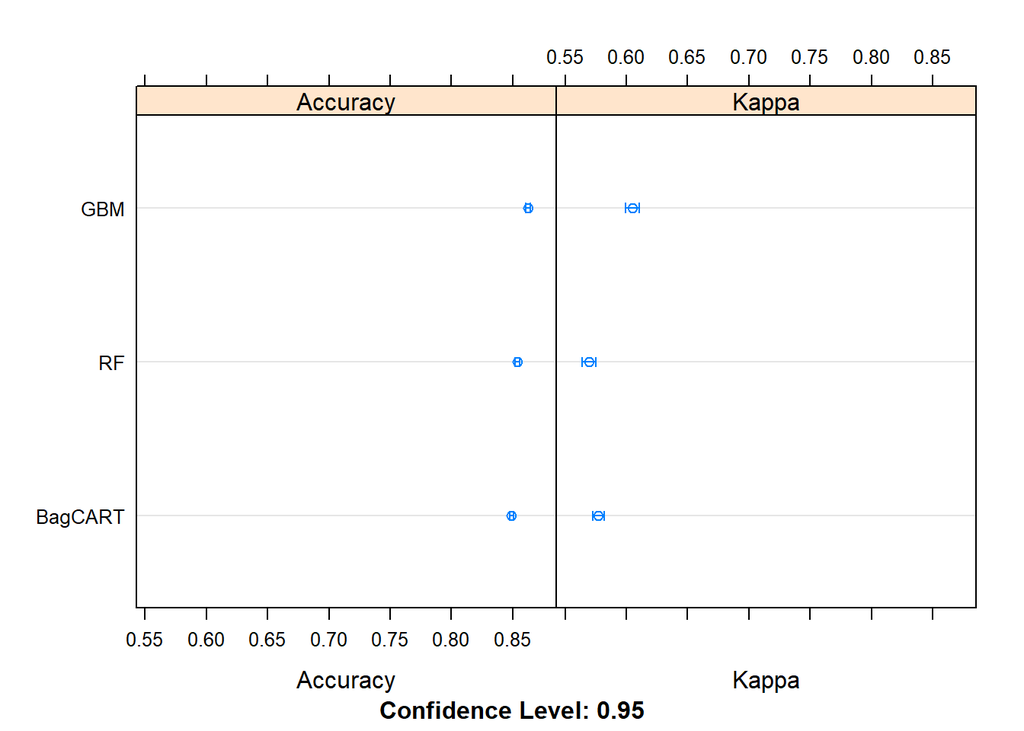

```r
dotplot(results)
```

## 6. Finalize Model and Present Results

Once we have narrow down to a model that we believe can make accurate predictions on unseen data, we are ready to finalize it. Finalizing a model may involve sub-tasks such as:

- Using an optimal model tuned to make predictions on unseen data.
- Creating a standalone model using the tuned parameters
- Saving an optimal model to file for later use.

### 6.a) Predictions on validation dataset

```r
predictions <- predict(fit.final3, newdata=validation)
confusionMatrix(predictions, validation$targetVar)
```

```
## Confusion Matrix and Statistics
##
##           Reference
## Prediction <=50K  >50K
##      <=50K 10699  1404
##      >50K    660  2296
##
##                Accuracy : 0.8629
##                  95% CI : (0.8573, 0.8684)
##     No Information Rate : 0.7543
##     P-Value [Acc > NIR] : < 2.2e-16
##
##                   Kappa : 0.6033
##  Mcnemar's Test P-Value : < 2.2e-16
##
##             Sensitivity : 0.9419
##             Specificity : 0.6205
##          Pos Pred Value : 0.8840
##          Neg Pred Value : 0.7767
##              Prevalence : 0.7543
##          Detection Rate : 0.7105
##    Detection Prevalence : 0.8037
##       Balanced Accuracy : 0.7812
##
##        'Positive' Class : <=50K
##
```

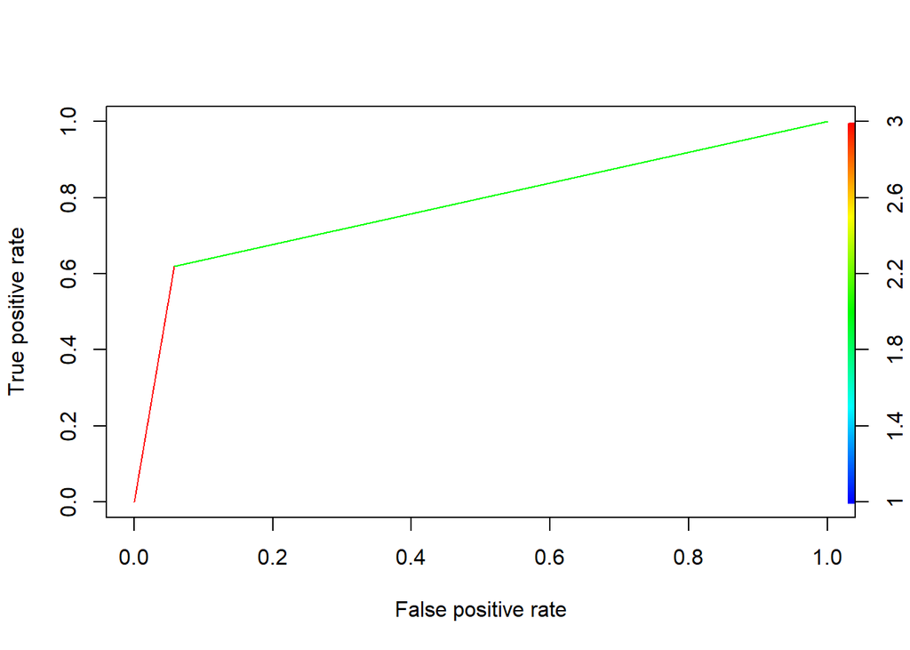

```r
pred <- prediction(as.numeric(predictions), as.numeric(validation$targetVar))
perf <- performance(pred, measure = "tpr", x.measure = "fpr")
plot(perf, colorize=TRUE)
```

```r
auc <- performance(pred, measure = "auc")
auc <- auc@y.values[[1]]
auc
```

```
## [1] 0.7812184
```

### 6.b) Create standalone model on entire training dataset

```r
startTimeModule <- proc.time()
set.seed(seedNum)
grid <- expand.grid(.n.trees=200, .shrinkage=0.1, .interaction.depth=3, .n.minobsinnode=3)
finalModel <- train(targetVar~., data=entireDataset, method="gbm", metric=metricTarget, tuneGrid=grid, trControl=control, verbose=F)
print(finalModel)
```

[output not shown]

```r
proc.time()-startTimeModule
```

```
##    user  system elapsed
##  649.11    0.46  649.84
```

### 6.c) Save model for later use

```r
#saveRDS(finalModel, "./finalModel_BinaryClass.rds")
```

```r
proc.time()-startTimeScript
```

```
##     user   system  elapsed
## 90955.61   275.23 91265.22
```